# Contagious Yawning in Dogs: Prosocial Experiment Analysis (Part 1)

Scott Claessens and Patrick Neilands

2019-12-19

The purpose of this document is to analyse data from a new experiment on contagious yawning in dogs in the presence of either a prosocial or antisocial demonstrator.

# 0. Setup

Load the data.

```r
d <-
  read.csv("data/yawnProsocial.csv") %>%
  as_tibble() %>%
  # create dummy variables for analysis
  mutate(condition = ifelse(condition == "Anti-Social", 0, 1),
         trial     = ifelse(trial == 1, 0, 1))

d
```

| ID | condition | numberYawns | trial | secs |
| --- | --- | --- | --- | --- |
| Axl | 1 | 0 | 1 | 300 |
| Smith | 1 | 0 | 1 | 300 |
| Dice | 1 | 0 | 0 | 300 |
| Tweed | 1 | 0 | 1 | 300 |
| Plum | 1 | 0 | 0 | 300 |
| Jack | 1 | 0 | 0 | 300 |
| Kohi | 1 | 0 | 1 | 300 |
| Manny | 1 | 0 | 1 | 300 |
| Meg | 1 | 1 | 0 | 300 |
| Ruby | 1 | 1 | 0 | 300 |

[output cut: 54 more lines]

We can visualize the number of yawns across the sample as a whole.

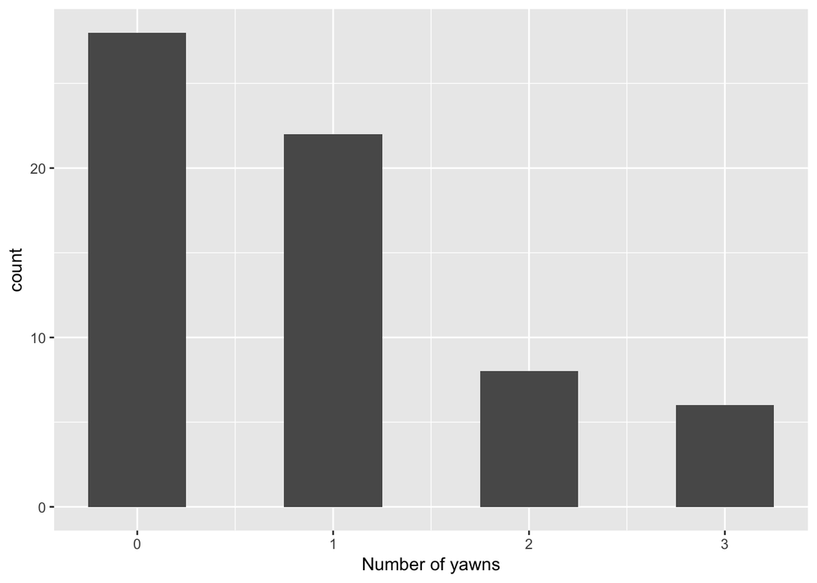

We can also see how this varies by condition.

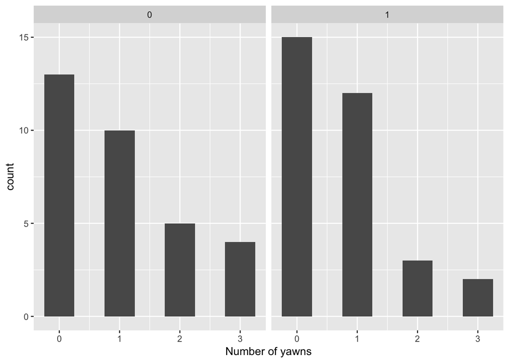

We will initially treat this as zero-inflated Poisson data; however, this specific dataset does not look too zero-inflated. Later, we will re-run models with other distributions and see if our results are robust to this assumption.

# 1. Fit zero-inflated Poisson models

## 1.1. Intercept-only model

We utlise a Bayesian multilevel modelling approach, including random effects for individual dogs. Throughout, we use the same linear model to predict $\lambda_i$ (the rate of yawning) and $p_i$ (the probability of the yawning process never even getting started). The latter is called `zi` inside the model formula.

Fit an intercept-only model.

```
##  Family: zero_inflated_poisson
##   Links: mu = log; zi = logit
## Formula: numberYawns ~ 0 + intercept + offset(log(secs)) + (0 + intercept | ID)
##          zi ~ 0 + intercept + (0 + intercept | ID)
##    Data: d (Number of observations: 64)
## Samples: 4 chains, each with iter = 2000; warmup = 1000; thin = 1;
##          total post-warmup samples = 4000
##
## Group-Level Effects:
## ~ID (Number of levels: 32)
##                  Estimate Est.Error l-95% CI u-95% CI Rhat Bulk_ESS Tail_ESS
## sd(intercept)        0.27      0.19     0.01     0.71 1.00     1197     1565
## sd(zi_intercept)     0.54      0.56     0.02     1.98 1.00     2436     1930
##
## Population-Level Effects:
##              Estimate Est.Error l-95% CI u-95% CI Rhat Bulk_ESS Tail_ESS
## intercept       -5.76      0.19    -6.13    -5.39 1.00     2151     2681
## zi_intercept    -2.33      1.16    -5.33    -0.74 1.00     2370     1895
##
## Samples were drawn using sampling(NUTS). For each parameter, Eff.Sample
## is a crude measure of effective sample size, and Rhat is the potential
## scale reduction factor on split chains (at convergence, Rhat = 1).
```

What priors did we use?

| prior | class | coef | group | resp | dpar | nlpar | bound |
| --- | --- | --- | --- | --- | --- | --- | --- |
|  | b |  |  |  |  |  |  |
| student_t(3, -2, 10) | b | intercept |  |  |  |  |  |
|  | b |  |  |  | zi |  |  |
| logistic(0, 1) | b | intercept |  |  | zi |  |  |
| student_t(3, 0, 10) | sd |  |  |  |  |  |  |
| student_t(3, 0, 0.5) | sd |  |  |  | zi |  |  |
|  | sd |  | ID |  |  |  |  |
|  | sd | intercept | ID |  |  |  |  |
|  | sd |  | ID |  | zi |  |  |
|  | sd | intercept | ID |  | zi |  |  |

Let’s interpret each parameter in turn. The zero-inflation parameter `zi` is -2.33. This is on the logit scale, so we need to calculate the inverse logit.

```r
post <- posterior_samples(m3.1)

1 - inv_logit_scaled(post$b_zi_intercept) %>% # prob of yawning process getting started
  median() %>%
  round(2)
```

```
## [1] 0.89
```

The median probability of the yawning process getting started is 0.89. This is quite probable, meaning we may be justified in switching to a non-zero-inflated Poisson process. We’ll do this later.

Let’s calculate the average yawning rate once the yawning process gets started.

```r
(exp(post$b_intercept) * 60) %>% # Yawning rate (per min)
  median() %>%
  round(2)
```

```
## [1] 0.19
```

The dogs yawn 0.19 times a minute, on average. Let’s split this by ID.

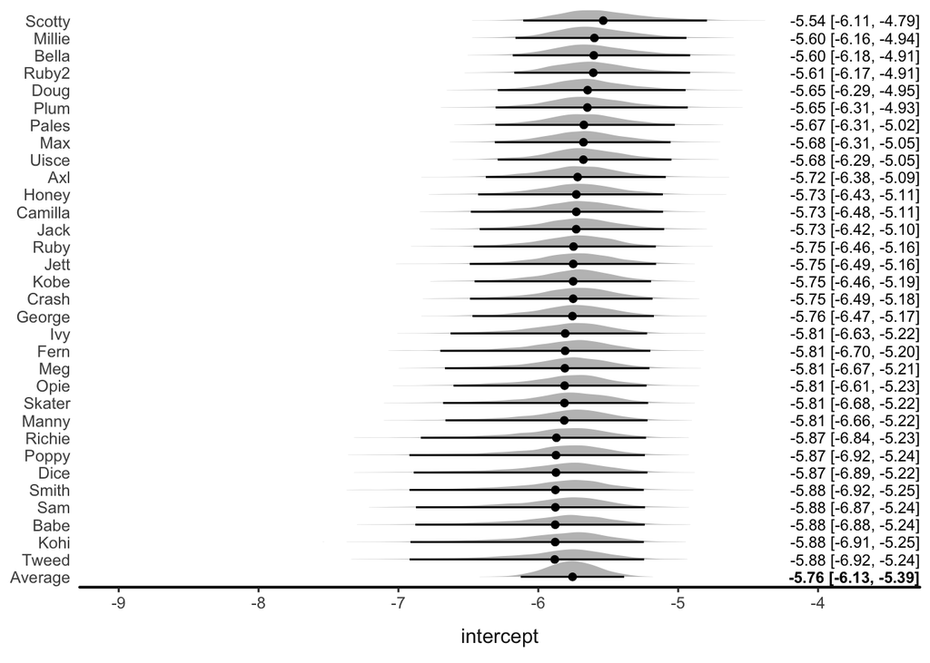

Remember, this is on the log scale. But it seems like there isn’t much variation in yawning rates across dogs.

## 1.2. Condition-only model

Next, we add condition to the model, also as a random effect grouped by individual dogs.

```
##  Family: zero_inflated_poisson
##   Links: mu = log; zi = logit
## Formula: numberYawns ~ 0 + intercept + condition + offset(log(secs)) + (0 + intercept + condition | ID)
##          zi ~ 0 + intercept + condition + (0 + intercept + condition | ID)
##    Data: d (Number of observations: 64)
## Samples: 4 chains, each with iter = 2000; warmup = 1000; thin = 1;
##          total post-warmup samples = 4000
##
## Group-Level Effects:
## ~ID (Number of levels: 32)
##                                Estimate Est.Error l-95% CI u-95% CI Rhat Bulk_ESS Tail_ESS
## sd(intercept)                      0.29      0.22     0.01     0.80 1.00     1677     2658
## sd(condition)                      0.42      0.30     0.02     1.14 1.00     1533     1798
## sd(zi_intercept)                   0.52      0.50     0.02     1.86 1.00     3165     2052
## sd(zi_condition)                   0.51      0.51     0.02     1.80 1.00     3939     2428
## cor(intercept,condition)          -0.16      0.57    -0.97     0.93 1.00     2645     2704
## cor(zi_intercept,zi_condition)    -0.01      0.59    -0.96     0.94 1.00     5220     2464
##
## Population-Level Effects:
##              Estimate Est.Error l-95% CI u-95% CI Rhat Bulk_ESS Tail_ESS
## intercept       -5.65      0.23    -6.13    -5.22 1.00     2529     2542
## condition       -0.35      0.32    -1.00     0.27 1.00     3443     3178
## zi_intercept    -2.43      1.21    -5.49    -0.64 1.00     2818     2180
## zi_condition    -0.36      0.90    -2.16     1.40 1.00     5173     3036
##
## Samples were drawn using sampling(NUTS). For each parameter, Eff.Sample
## is a crude measure of effective sample size, and Rhat is the potential
## scale reduction factor on split chains (at convergence, Rhat = 1).
```

What priors did we use?

| prior | class | coef | group | resp | dpar | nlpar | bound |
| --- | --- | --- | --- | --- | --- | --- | --- |
|  | b |  |  |  |  |  |  |
| normal(0, 1) | b | condition |  |  |  |  |  |
| student_t(3, -2, 10) | b | intercept |  |  |  |  |  |
|  | b |  |  |  | zi |  |  |
| normal(0, 1) | b | condition |  |  | zi |  |  |
| logistic(0, 1) | b | intercept |  |  | zi |  |  |
| lkj_corr_cholesky(1) | L |  |  |  |  |  |  |
|  | L |  | ID |  |  |  |  |
| student_t(3, 0, 10) | sd |  |  |  |  |  |  |
| student_t(3, 0, 0.5) | sd |  |  |  | zi |  |  |

[output cut: 6 more lines]

The condition parameter has 95% CIs crossing zero, suggesting that there is no difference in yawning rates between conditions. Let’s calculate this directly.

```r
post <- posterior_samples(m3.2)

# Yawning rate (per min) in Anti-Social condition
(exp(post$b_intercept) * 60) %>%
  median() %>%
  round(2)
```

```
## [1] 0.21
```

```r
# Yawning rate (per min) in Pro-Social condition
(exp(post$b_intercept + post$b_condition) * 60) %>%
  median() %>%
  round(2)
```

```
## [1] 0.15
```

Psoterior probability mass shows that the difference between these is not substantial.

```r
(sum(post$b_condition < 0) / length(post$b_condition)) %>% round(2)
```

```
## [1] 0.86
```

Let’s visualise this lack of a difference on the “Yawning rate (per min)” scale.

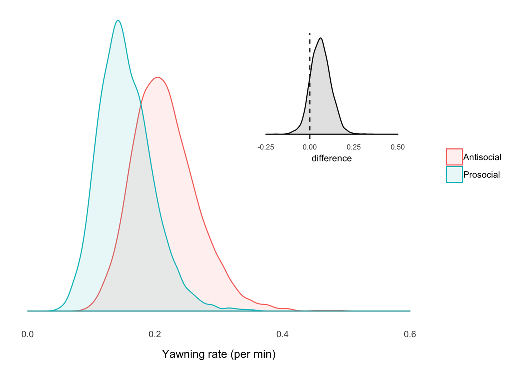

How does the effect of condition vary across individual dogs?

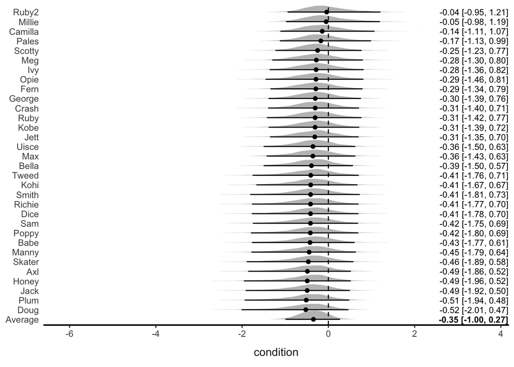

Condition doesn’t seem to have an effect for any individual dog either.

## 1.3. Trial-only model

```
##  Family: zero_inflated_poisson
##   Links: mu = log; zi = logit
## Formula: numberYawns ~ 0 + intercept + trial + offset(log(secs)) + (0 + intercept + trial | ID)
##          zi ~ 0 + intercept + trial + (0 + intercept + trial | ID)
##    Data: d (Number of observations: 64)
## Samples: 4 chains, each with iter = 2000; warmup = 1000; thin = 1;
##          total post-warmup samples = 4000
##
## Group-Level Effects:
## ~ID (Number of levels: 32)
##                            Estimate Est.Error l-95% CI u-95% CI Rhat Bulk_ESS Tail_ESS
## sd(intercept)                  0.28      0.21     0.01     0.78 1.00     1363     1757
## sd(trial)                      0.48      0.33     0.02     1.24 1.00     1408     1856
## sd(zi_intercept)               0.51      0.52     0.02     1.87 1.00     2159     1643
## sd(zi_trial)                   0.50      0.50     0.02     1.77 1.00     2954     1722
## cor(intercept,trial)          -0.11      0.57    -0.96     0.93 1.00     1794     2285
## cor(zi_intercept,zi_trial)     0.00      0.57    -0.95     0.94 1.00     4265     2105
##
## Population-Level Effects:
##              Estimate Est.Error l-95% CI u-95% CI Rhat Bulk_ESS Tail_ESS
## intercept       -5.67      0.22    -6.12    -5.25 1.00     2745     2562
## trial           -0.36      0.33    -1.06     0.25 1.00     2844     3005
## zi_intercept    -2.62      1.28    -5.67    -0.78 1.00     2684     2029
## zi_trial        -0.24      0.91    -2.05     1.53 1.00     4132     3222
##
## Samples were drawn using sampling(NUTS). For each parameter, Eff.Sample
## is a crude measure of effective sample size, and Rhat is the potential
## scale reduction factor on split chains (at convergence, Rhat = 1).
```

Priors.

| prior | class | coef | group | resp | dpar | nlpar | bound |
| --- | --- | --- | --- | --- | --- | --- | --- |
|  | b |  |  |  |  |  |  |
| student_t(3, -2, 10) | b | intercept |  |  |  |  |  |
| normal(0, 1) | b | trial |  |  |  |  |  |
|  | b |  |  |  | zi |  |  |
| logistic(0, 1) | b | intercept |  |  | zi |  |  |
| normal(0, 1) | b | trial |  |  | zi |  |  |
| lkj_corr_cholesky(1) | L |  |  |  |  |  |  |
|  | L |  | ID |  |  |  |  |
| student_t(3, 0, 10) | sd |  |  |  |  |  |  |
| student_t(3, 0, 0.5) | sd |  |  |  | zi |  |  |

[output cut: 6 more lines]

## 1.4. Condition + Trial model

```
##  Family: zero_inflated_poisson
##   Links: mu = log; zi = logit
## Formula: numberYawns ~ 0 + intercept + condition + trial + offset(log(secs)) + (0 + intercept + condition + trial | ID)
##          zi ~ 0 + intercept + condition + trial + (0 + intercept + condition + trial | ID)
##    Data: d (Number of observations: 64)
## Samples: 4 chains, each with iter = 2000; warmup = 1000; thin = 1;
##          total post-warmup samples = 4000
##
## Group-Level Effects:
## ~ID (Number of levels: 32)
##                                Estimate Est.Error l-95% CI u-95% CI Rhat Bulk_ESS Tail_ESS
## sd(intercept)                      0.31      0.24     0.01     0.88 1.00     1985     2481
## sd(condition)                      0.39      0.30     0.01     1.14 1.00     2085     2144
## sd(trial)                          0.46      0.34     0.02     1.26 1.00     1423     1586
## sd(zi_intercept)                   0.51      0.52     0.02     1.86 1.00     3631     2451
## sd(zi_condition)                   0.51      0.54     0.01     1.86 1.00     3939     1516
## sd(zi_trial)                       0.51      0.51     0.02     1.81 1.00     4518     2651
## cor(intercept,condition)          -0.11      0.50    -0.92     0.84 1.00     4613     2962
## cor(intercept,trial)              -0.08      0.50    -0.90     0.84 1.00     3926     3286
## cor(condition,trial)              -0.05      0.49    -0.88     0.85 1.00     3272     3428
## cor(zi_intercept,zi_condition)    -0.00      0.50    -0.88     0.88 1.00     7153     2591
## cor(zi_intercept,zi_trial)         0.01      0.50    -0.88     0.89 1.00     7812     2764
## cor(zi_condition,zi_trial)         0.00      0.51    -0.89     0.89 1.00     4001     2850
##
## Population-Level Effects:
##              Estimate Est.Error l-95% CI u-95% CI Rhat Bulk_ESS Tail_ESS
## intercept       -5.58      0.27    -6.14    -5.08 1.00     3306     2969
## condition       -0.32      0.32    -0.97     0.33 1.00     4365     3245
## trial           -0.34      0.34    -1.02     0.31 1.00     4362     2949
## zi_intercept    -2.59      1.31    -5.75    -0.63 1.00     3069     2391
## zi_condition    -0.40      0.88    -2.09     1.38 1.00     6724     2974
## zi_trial        -0.27      0.90    -2.10     1.46 1.00     6343     3362
##
## Samples were drawn using sampling(NUTS). For each parameter, Eff.Sample
## is a crude measure of effective sample size, and Rhat is the potential
## scale reduction factor on split chains (at convergence, Rhat = 1).
```

Priors.

| prior | class | coef | group | resp | dpar | nlpar | bound |
| --- | --- | --- | --- | --- | --- | --- | --- |
|  | b |  |  |  |  |  |  |
| normal(0, 1) | b | condition |  |  |  |  |  |
| student_t(3, -2, 10) | b | intercept |  |  |  |  |  |
| normal(0, 1) | b | trial |  |  |  |  |  |
|  | b |  |  |  | zi |  |  |
| normal(0, 1) | b | condition |  |  | zi |  |  |
| logistic(0, 1) | b | intercept |  |  | zi |  |  |
| normal(0, 1) | b | trial |  |  | zi |  |  |
| lkj_corr_cholesky(1) | L |  |  |  |  |  |  |
|  | L |  | ID |  |  |  |  |

[output cut: 10 more lines]

## 1.5. Interaction model

```
##  Family: zero_inflated_poisson
##   Links: mu = log; zi = logit
## Formula: numberYawns ~ 0 + intercept + condition * trial + offset(log(secs)) + (0 + intercept + condition * trial | ID)
##          zi ~ 0 + intercept + condition * trial + (0 + intercept + condition * trial | ID)
##    Data: d (Number of observations: 64)
## Samples: 4 chains, each with iter = 2000; warmup = 1000; thin = 1;
##          total post-warmup samples = 4000
##
## Group-Level Effects:
## ~ID (Number of levels: 32)
##                                      Estimate Est.Error l-95% CI u-95% CI Rhat Bulk_ESS Tail_ESS
## sd(intercept)                            0.31      0.22     0.02     0.85 1.00     1771     2233
## sd(condition)                            0.42      0.33     0.02     1.23 1.00     1895     2260
## sd(trial)                                0.49      0.36     0.03     1.37 1.00     1631     2236
## sd(condition:trial)                      0.78      0.60     0.03     2.20 1.00     1505     1695
## sd(zi_intercept)                         0.51      0.50     0.02     1.77 1.00     3037     2535
## sd(zi_condition)                         0.48      0.46     0.02     1.64 1.00     3186     1779
## sd(zi_trial)                             0.50      0.50     0.02     1.78 1.00     3537     1818
## sd(zi_condition:trial)                   0.55      0.64     0.02     2.11 1.00     4232     2182
## cor(intercept,condition)                -0.11      0.45    -0.86     0.75 1.00     3363     3102
## cor(intercept,trial)                    -0.07      0.44    -0.84     0.77 1.00     3240     2652
## cor(condition,trial)                    -0.03      0.45    -0.82     0.80 1.00     2960     3187
## cor(intercept,condition:trial)          -0.03      0.45    -0.82     0.79 1.00     3032     2582
## cor(condition,condition:trial)          -0.06      0.45    -0.84     0.77 1.00     3548     3319
## cor(trial,condition:trial)              -0.09      0.45    -0.84     0.77 1.00     2864     3558
## cor(zi_intercept,zi_condition)          -0.00      0.45    -0.80     0.83 1.00     5731     2813
## cor(zi_intercept,zi_trial)              -0.00      0.45    -0.82     0.80 1.00     6039     2585
## cor(zi_condition,zi_trial)               0.01      0.44    -0.78     0.82 1.00     4240     3109
## cor(zi_intercept,zi_condition:trial)     0.02      0.45    -0.81     0.82 1.00     5886     2408
## cor(zi_condition,zi_condition:trial)     0.01      0.45    -0.81     0.82 1.00     3903     2649
## cor(zi_trial,zi_condition:trial)        -0.01      0.44    -0.80     0.80 1.00     3261     3168
##
## Population-Level Effects:
##                    Estimate Est.Error l-95% CI u-95% CI Rhat Bulk_ESS Tail_ESS
## intercept             -5.65      0.28    -6.22    -5.10 1.00     2156     2511
## condition             -0.18      0.39    -0.94     0.57 1.00     2442     2547
## trial                 -0.19      0.40    -1.00     0.59 1.00     2810     2859
## condition:trial       -0.55      0.59    -1.76     0.59 1.00     2720     3033
## zi_intercept          -2.69      1.37    -5.99    -0.69 1.00     2486     2090
## zi_condition          -0.46      0.89    -2.21     1.27 1.00     5090     3192
## zi_trial              -0.32      0.92    -2.15     1.50 1.00     5378     2959
## zi_condition:trial    -0.11      0.96    -1.99     1.78 1.00     5936     3119
##
## Samples were drawn using sampling(NUTS). For each parameter, Eff.Sample
## is a crude measure of effective sample size, and Rhat is the potential
## scale reduction factor on split chains (at convergence, Rhat = 1).
```

What priors did we use?

| prior | class | coef | group | resp | dpar | nlpar | bound |
| --- | --- | --- | --- | --- | --- | --- | --- |
|  | b |  |  |  |  |  |  |
| normal(0, 1) | b | condition |  |  |  |  |  |
| normal(0, 1) | b | condition:trial |  |  |  |  |  |
| student_t(3, -2, 10) | b | intercept |  |  |  |  |  |
| normal(0, 1) | b | trial |  |  |  |  |  |
|  | b |  |  |  | zi |  |  |
| normal(0, 1) | b | condition |  |  | zi |  |  |
| normal(0, 1) | b | condition:trial |  |  | zi |  |  |
| logistic(0, 1) | b | intercept |  |  | zi |  |  |
| normal(0, 1) | b | trial |  |  | zi |  |  |

[output cut: 14 more lines]

Are there any differences between cells in the 2x2 design?

```r
post <- posterior_samples(m3.5)

# Yawning rate (per min)
anti1rate <- exp(post$b_intercept) * 60
anti2rate <- exp(post$b_intercept + post$b_trial) * 60
pro1rate  <- exp(post$b_intercept + post$b_condition) * 60
pro2rate  <- exp(post$b_intercept + post$b_condition + post$b_trial + post$`b_condition:trial`) * 60

diff1 <- anti1rate - anti2rate
diff2 <- anti1rate - pro1rate
diff3 <- anti1rate - pro2rate
diff4 <- anti2rate - pro1rate
diff5 <- anti2rate - pro2rate
diff6 <- pro1rate  - pro2rate

(sum(diff1 > 0) / length(diff1)) %>% round(2)
```

```
## [1] 0.68
```

```r
(sum(diff2 > 0) / length(diff2)) %>% round(2)
```

```
## [1] 0.67
```

```r
(sum(diff3 > 0) / length(diff3)) %>% round(2)
```

```
## [1] 0.96
```

```r
(sum(diff4 > 0) / length(diff4)) %>% round(2)
```

```
## [1] 0.48
```

```r
(sum(diff5 > 0) / length(diff5)) %>% round(2)
```

```
## [1] 0.92
```

```r
(sum(diff6 > 0) / length(diff6)) %>% round(2)
```

```
## [1] 0.93
```

Is there an interaction effect?

```r
(sum(diff2 - diff5 < 0) / length(diff2)) %>% round(2)
```

```
## [1] 0.73
```

No.

## 1.6. Compare models

```r
loo_compare(m3.1, m3.2, m3.3, m3.4, m3.5)
```

```
##      elpd_diff se_diff
## m3.1  0.0       0.0
## m3.3 -0.8       1.0
## m3.2 -1.0       1.0
## m3.4 -1.8       1.3
## m3.5 -2.2       1.7
```

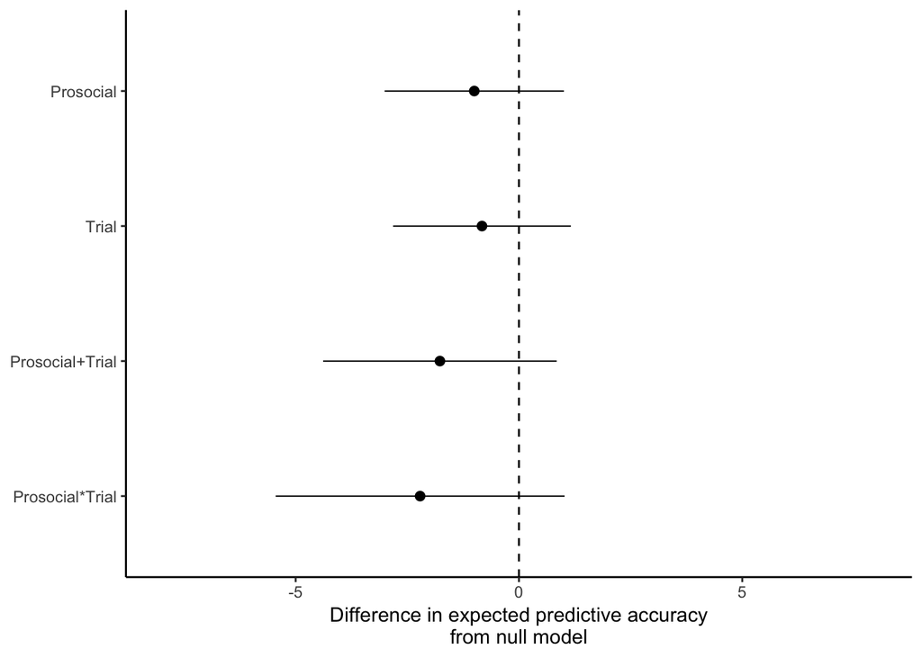

# 2. Fit Poisson models

## 2.1. Intercept-only model

Fit an intercept-only model with no zero-inflation assumption.

```
##  Family: poisson
##   Links: mu = log
## Formula: numberYawns ~ 1 + offset(log(secs)) + (1 | ID)
##    Data: d (Number of observations: 64)
## Samples: 4 chains, each with iter = 2000; warmup = 1000; thin = 1;
##          total post-warmup samples = 4000
##
## Group-Level Effects:
## ~ID (Number of levels: 32)
##               Estimate Est.Error l-95% CI u-95% CI Rhat Bulk_ESS Tail_ESS
## sd(Intercept)     0.34      0.22     0.02     0.82 1.00     1005     1523
##
## Population-Level Effects:
##           Estimate Est.Error l-95% CI u-95% CI Rhat Bulk_ESS Tail_ESS
## Intercept    -5.91      0.16    -6.27    -5.62 1.00     3228     2616
##
## Samples were drawn using sampling(NUTS). For each parameter, Eff.Sample
## is a crude measure of effective sample size, and Rhat is the potential
## scale reduction factor on split chains (at convergence, Rhat = 1).
```

What priors did we use?

| prior | class | coef | group | resp | dpar | nlpar | bound |
| --- | --- | --- | --- | --- | --- | --- | --- |
| student_t(3, 0, 10) | Intercept |  |  |  |  |  |  |
| student_t(3, 0, 10) | sd |  |  |  |  |  |  |
|  | sd |  | ID |  |  |  |  |
|  | sd | Intercept | ID |  |  |  |  |

Calculate the average yawning rate.

```r
post <- posterior_samples(m4.1)

(exp(post$b_Intercept) * 60) %>% # Yawning rate (per min)
  median() %>%
  round(2)
```

```
## [1] 0.16
```

The dogs yawn 0.16 times a minute, on average. Not much different from the zero-inflated model. Quick model comparison?

```r
loo_compare(m3.1, m4.1)
```

```
##      elpd_diff se_diff
## m4.1  0.0       0.0
## m3.1 -0.2       0.8
```

The two models perform no differently.

## 2.2. Condition-only model

Add condition to the model.

```
##  Family: poisson
##   Links: mu = log
## Formula: numberYawns ~ 0 + intercept + condition + offset(log(secs)) + (0 + intercept + condition | ID)
##    Data: d (Number of observations: 64)
## Samples: 4 chains, each with iter = 2000; warmup = 1000; thin = 1;
##          total post-warmup samples = 4000
##
## Group-Level Effects:
## ~ID (Number of levels: 32)
##                          Estimate Est.Error l-95% CI u-95% CI Rhat Bulk_ESS Tail_ESS
## sd(intercept)                0.37      0.25     0.01     0.96 1.00     1290     1773
## sd(condition)                0.45      0.33     0.02     1.21 1.00     1206     1750
## cor(intercept,condition)    -0.15      0.57    -0.97     0.93 1.00     2515     2591
##
## Population-Level Effects:
##           Estimate Est.Error l-95% CI u-95% CI Rhat Bulk_ESS Tail_ESS
## intercept    -5.82      0.22    -6.29    -5.43 1.00     3093     2401
## condition    -0.32      0.31    -0.95     0.26 1.00     3205     2886
##
## Samples were drawn using sampling(NUTS). For each parameter, Eff.Sample
## is a crude measure of effective sample size, and Rhat is the potential
## scale reduction factor on split chains (at convergence, Rhat = 1).
```

What priors did we use?

| prior | class | coef | group | resp | dpar | nlpar | bound |
| --- | --- | --- | --- | --- | --- | --- | --- |
|  | b |  |  |  |  |  |  |
| normal(0, 1) | b | condition |  |  |  |  |  |
| student_t(3, -2, 10) | b | intercept |  |  |  |  |  |
| lkj_corr_cholesky(1) | L |  |  |  |  |  |  |
|  | L |  | ID |  |  |  |  |
| student_t(3, 0, 10) | sd |  |  |  |  |  |  |
|  | sd |  | ID |  |  |  |  |
|  | sd | condition | ID |  |  |  |  |
|  | sd | intercept | ID |  |  |  |  |

Difference between conditions?

```r
post <- posterior_samples(m4.2)

# Yawning rate (per min) in Anti-Social condition
(exp(post$b_intercept) * 60) %>%
  median() %>%
  round(2)
```

```
## [1] 0.18
```

```r
# Yawning rate (per min) in Pro-Social condition
(exp(post$b_intercept + post$b_condition) * 60) %>%
  median() %>%
  round(2)
```

```
## [1] 0.13
```

Estimates are not much different from the zero-inflated model. Again, posterior probability mass shows that the difference between these is not substantial.

```r
(sum(post$b_condition < 0) / length(post$b_condition)) %>% round(2)
```

```
## [1] 0.86
```

Let’s visualise the difference with our Poisson model.

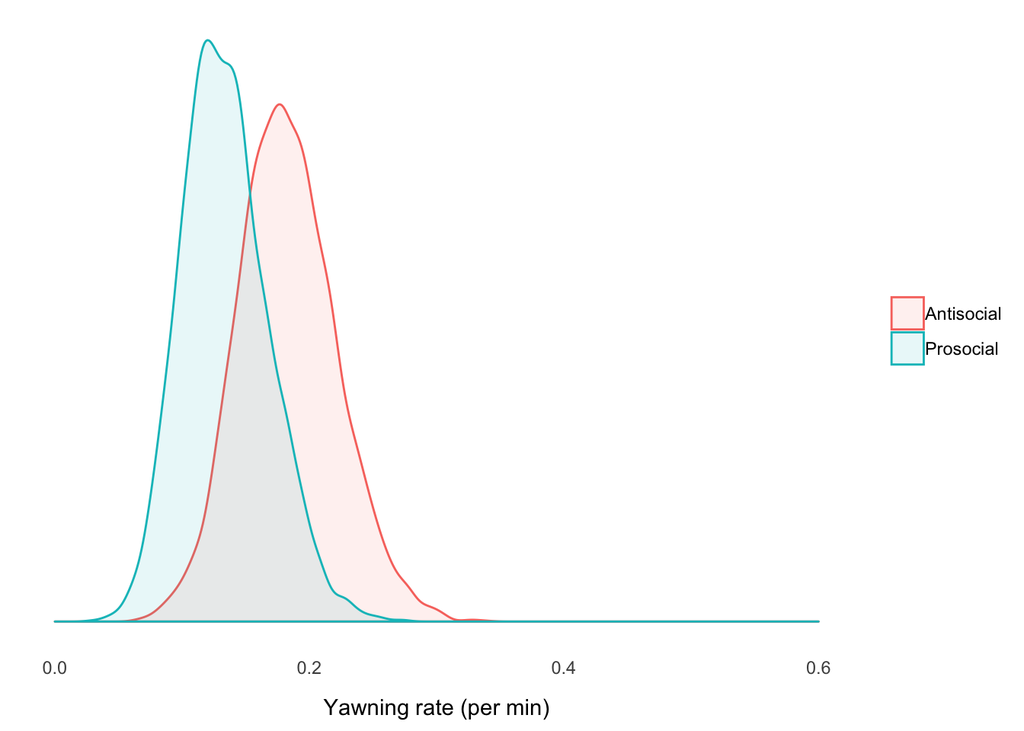

Quick model comparison?

```r
loo_compare(m3.2, m4.2)
```

```
##      elpd_diff se_diff
## m4.2  0.0       0.0
## m3.2 -0.2       0.7
```

The model types are no different.

## 2.3. Trial-only model

```
##  Family: poisson
##   Links: mu = log
## Formula: numberYawns ~ 0 + intercept + trial + offset(log(secs)) + (0 + intercept + trial | ID)
##    Data: d (Number of observations: 64)
## Samples: 4 chains, each with iter = 2000; warmup = 1000; thin = 1;
##          total post-warmup samples = 4000
##
## Group-Level Effects:
## ~ID (Number of levels: 32)
##                      Estimate Est.Error l-95% CI u-95% CI Rhat Bulk_ESS Tail_ESS
## sd(intercept)            0.33      0.24     0.02     0.87 1.00     1402     2227
## sd(trial)                0.54      0.36     0.03     1.36 1.00     1247     1645
## cor(intercept,trial)    -0.10      0.56    -0.95     0.92 1.00     2224     2661
##
## Population-Level Effects:
##           Estimate Est.Error l-95% CI u-95% CI Rhat Bulk_ESS Tail_ESS
## intercept    -5.79      0.20    -6.22    -5.43 1.00     4508     2758
## trial        -0.39      0.32    -1.05     0.19 1.00     3905     2749
##
## Samples were drawn using sampling(NUTS). For each parameter, Eff.Sample
## is a crude measure of effective sample size, and Rhat is the potential
## scale reduction factor on split chains (at convergence, Rhat = 1).
```

Priors.

| prior | class | coef | group | resp | dpar | nlpar | bound |
| --- | --- | --- | --- | --- | --- | --- | --- |
|  | b |  |  |  |  |  |  |
| student_t(3, -2, 10) | b | intercept |  |  |  |  |  |
| normal(0, 1) | b | trial |  |  |  |  |  |
| lkj_corr_cholesky(1) | L |  |  |  |  |  |  |
|  | L |  | ID |  |  |  |  |
| student_t(3, 0, 10) | sd |  |  |  |  |  |  |
|  | sd |  | ID |  |  |  |  |
|  | sd | intercept | ID |  |  |  |  |
|  | sd | trial | ID |  |  |  |  |

## 2.4. Condition + Trial model

```
##  Family: poisson
##   Links: mu = log
## Formula: numberYawns ~ 0 + intercept + condition + trial + offset(log(secs)) + (0 + intercept + condition + trial | ID)
##    Data: d (Number of observations: 64)
## Samples: 4 chains, each with iter = 2000; warmup = 1000; thin = 1;
##          total post-warmup samples = 4000
##
## Group-Level Effects:
## ~ID (Number of levels: 32)
##                          Estimate Est.Error l-95% CI u-95% CI Rhat Bulk_ESS Tail_ESS
## sd(intercept)                0.37      0.26     0.02     0.97 1.00     1324     1487
## sd(condition)                0.42      0.32     0.01     1.21 1.00     1662     1986
## sd(trial)                    0.53      0.37     0.02     1.40 1.00     1303     1832
## cor(intercept,condition)    -0.11      0.51    -0.92     0.84 1.00     2726     2933
## cor(intercept,trial)        -0.07      0.50    -0.90     0.85 1.00     2222     2324
## cor(condition,trial)        -0.04      0.49    -0.89     0.85 1.00     2177     2596
##
## Population-Level Effects:
##           Estimate Est.Error l-95% CI u-95% CI Rhat Bulk_ESS Tail_ESS
## intercept    -5.71      0.25    -6.23    -5.27 1.00     2600     2465
## condition    -0.30      0.31    -0.94     0.28 1.00     3615     2902
## trial        -0.36      0.33    -1.04     0.26 1.00     3284     2768
##
## Samples were drawn using sampling(NUTS). For each parameter, Eff.Sample
## is a crude measure of effective sample size, and Rhat is the potential
## scale reduction factor on split chains (at convergence, Rhat = 1).
```

Priors.

| prior | class | coef | group | resp | dpar | nlpar | bound |
| --- | --- | --- | --- | --- | --- | --- | --- |
|  | b |  |  |  |  |  |  |
| normal(0, 1) | b | condition |  |  |  |  |  |
| student_t(3, -2, 10) | b | intercept |  |  |  |  |  |
| normal(0, 1) | b | trial |  |  |  |  |  |
| lkj_corr_cholesky(1) | L |  |  |  |  |  |  |
|  | L |  | ID |  |  |  |  |
| student_t(3, 0, 10) | sd |  |  |  |  |  |  |
|  | sd |  | ID |  |  |  |  |
|  | sd | condition | ID |  |  |  |  |
|  | sd | intercept | ID |  |  |  |  |

[output cut: 1 more lines]

## 2.5. Interaction model

```
##  Family: poisson
##   Links: mu = log
## Formula: numberYawns ~ 0 + intercept + condition * trial + offset(log(secs)) + (0 + intercept + condition * trial | ID)
##    Data: d (Number of observations: 64)
## Samples: 4 chains, each with iter = 2000; warmup = 1000; thin = 1;
##          total post-warmup samples = 4000
##
## Group-Level Effects:
## ~ID (Number of levels: 32)
##                                Estimate Est.Error l-95% CI u-95% CI Rhat Bulk_ESS Tail_ESS
## sd(intercept)                      0.36      0.25     0.01     0.93 1.00     1239     1269
## sd(condition)                      0.44      0.33     0.02     1.26 1.00     1722     1928
## sd(trial)                          0.54      0.38     0.03     1.45 1.00     1669     1983
## sd(condition:trial)                0.81      0.66     0.03     2.35 1.00     1427     1413
## cor(intercept,condition)          -0.10      0.45    -0.85     0.79 1.00     3139     2426
## cor(intercept,trial)              -0.06      0.44    -0.81     0.80 1.00     3063     2764
## cor(condition,trial)              -0.00      0.44    -0.81     0.81 1.00     2934     3188
## cor(intercept,condition:trial)    -0.03      0.43    -0.81     0.77 1.00     3248     2724
## cor(condition,condition:trial)    -0.07      0.44    -0.84     0.78 1.00     3117     3187
## cor(trial,condition:trial)        -0.07      0.45    -0.83     0.78 1.00     2787     3151
##
## Population-Level Effects:
##                 Estimate Est.Error l-95% CI u-95% CI Rhat Bulk_ESS Tail_ESS
## intercept          -5.78      0.25    -6.32    -5.31 1.00     2664     2558
## condition          -0.15      0.36    -0.90     0.54 1.00     2814     2787
## trial              -0.20      0.39    -0.98     0.54 1.00     2798     2429
## condition:trial    -0.59      0.57    -1.73     0.51 1.00     2854     2645
##
## Samples were drawn using sampling(NUTS). For each parameter, Eff.Sample
## is a crude measure of effective sample size, and Rhat is the potential
## scale reduction factor on split chains (at convergence, Rhat = 1).
```

What priors did we use?

| prior | class | coef | group | resp | dpar | nlpar | bound |
| --- | --- | --- | --- | --- | --- | --- | --- |
|  | b |  |  |  |  |  |  |
| normal(0, 1) | b | condition |  |  |  |  |  |
| normal(0, 1) | b | condition:trial |  |  |  |  |  |
| student_t(3, -2, 10) | b | intercept |  |  |  |  |  |
| normal(0, 1) | b | trial |  |  |  |  |  |
| lkj_corr_cholesky(1) | L |  |  |  |  |  |  |
|  | L |  | ID |  |  |  |  |
| student_t(3, 0, 10) | sd |  |  |  |  |  |  |
|  | sd |  | ID |  |  |  |  |
|  | sd | condition | ID |  |  |  |  |

[output cut: 3 more lines]

## 2.6. Compare models

Let’s compare every model fitted so far.

```r
loo_compare(m3.1, m3.2, m3.3, m3.4, m3.5,
            m4.1, m4.2, m4.3, m4.4, m4.5)
```

```
##      elpd_diff se_diff
## m4.1  0.0       0.0
## m3.1 -0.2       0.8
## m4.3 -0.6       1.2
## m4.2 -1.0       1.1
## m3.3 -1.0       1.5
## m3.2 -1.2       1.5
## m4.4 -1.6       1.6
## m4.5 -1.8       1.9
## m3.4 -1.9       1.8
## m3.5 -2.4       2.1
```

These models are indistinguishable.

# 3. Fit hurdle Poisson models

After running further model types for our main reanalysis, it transpired that a hurdle Poisson model fitted the data better than a zero-inflated Poisson model. We test this with our experimental data too.

## 3.1. Intercept-only model

```
##  Family: hurdle_poisson
##   Links: mu = log; hu = logit
## Formula: numberYawns ~ 0 + intercept + offset(log(secs)) + (0 + intercept | ID)
##          hu ~ 0 + intercept + (0 + intercept | ID)
##    Data: d (Number of observations: 64)
## Samples: 4 chains, each with iter = 2000; warmup = 1000; thin = 1;
##          total post-warmup samples = 4000
##
## Group-Level Effects:
## ~ID (Number of levels: 32)
##                  Estimate Est.Error l-95% CI u-95% CI Rhat Bulk_ESS Tail_ESS
## sd(intercept)        0.38      0.30     0.02     1.11 1.00     1622     2356
## sd(hu_intercept)     0.70      0.53     0.03     1.95 1.00     1080     2208
##
## Population-Level Effects:
##              Estimate Est.Error l-95% CI u-95% CI Rhat Bulk_ESS Tail_ESS
## intercept       -5.87      0.27    -6.47    -5.40 1.00     3248     2187
## hu_intercept    -0.28      0.30    -0.88     0.27 1.00     3868     2475
##
## Samples were drawn using sampling(NUTS). For each parameter, Eff.Sample
## is a crude measure of effective sample size, and Rhat is the potential
## scale reduction factor on split chains (at convergence, Rhat = 1).
```

Model comparison.

```r
loo_compare(m3.1, m9.1)
```

```
##      elpd_diff se_diff
## m3.1  0.0       0.0
## m9.1 -0.3       1.1
```

A hurdle model is no better than a zero-inflated model.

## 3.2. Condition-only model

```
##  Family: hurdle_poisson
##   Links: mu = log; hu = logit
## Formula: numberYawns ~ 0 + intercept + condition + offset(log(secs)) + (0 + intercept + condition | ID)
##          hu ~ 0 + intercept + condition + (0 + intercept + condition | ID)
##    Data: d (Number of observations: 64)
## Samples: 4 chains, each with iter = 2000; warmup = 1000; thin = 1;
##          total post-warmup samples = 4000
##
## Group-Level Effects:
## ~ID (Number of levels: 32)
##                                Estimate Est.Error l-95% CI u-95% CI Rhat Bulk_ESS Tail_ESS
## sd(intercept)                      0.42      0.34     0.01     1.29 1.00     1018     1353
## sd(condition)                      0.87      0.69     0.03     2.54 1.00      960     1234
## sd(hu_intercept)                   0.72      0.58     0.03     2.14 1.00      949     1279
## sd(hu_condition)                   0.60      0.76     0.02     2.43 1.00     1363     1837
## cor(intercept,condition)          -0.16      0.56    -0.97     0.92 1.00     1722     2278
## cor(hu_intercept,hu_condition)     0.08      0.57    -0.94     0.96 1.00     2389     1990
##
## Population-Level Effects:
##              Estimate Est.Error l-95% CI u-95% CI Rhat Bulk_ESS Tail_ESS
## intercept       -5.78      0.34    -6.54    -5.20 1.00     2488     1788
## condition       -0.59      0.54    -1.75     0.40 1.00     2718     2207
## hu_intercept    -0.38      0.39    -1.19     0.34 1.00     2879     2533
## hu_condition     0.18      0.49    -0.80     1.18 1.00     3437     3102
##
## Samples were drawn using sampling(NUTS). For each parameter, Eff.Sample
## is a crude measure of effective sample size, and Rhat is the potential
## scale reduction factor on split chains (at convergence, Rhat = 1).
```

Model comparison.

```r
loo_compare(m3.2, m9.2)
```

```
##      elpd_diff se_diff
## m3.2  0.0       0.0
## m9.2 -0.8       1.6
```

Both model classes perform similarly.

# 4. Fit various negative binomial models

For completion’s sake, we also fit NB models that deal with overdispersion in the data.

## 4.1. Negative binomial models

### 4.1.1. Intercept-only model

```
##  Family: negbinomial
##   Links: mu = log; shape = identity
## Formula: numberYawns ~ 0 + intercept + offset(log(secs)) + (0 + intercept | ID)
##    Data: d (Number of observations: 64)
## Samples: 4 chains, each with iter = 2000; warmup = 1000; thin = 1;
##          total post-warmup samples = 4000
##
## Group-Level Effects:
## ~ID (Number of levels: 32)
##               Estimate Est.Error l-95% CI u-95% CI Rhat Bulk_ESS Tail_ESS
## sd(intercept)     0.32      0.22     0.01     0.81 1.00     1098     1224
##
## Population-Level Effects:
##           Estimate Est.Error l-95% CI u-95% CI Rhat Bulk_ESS Tail_ESS
## intercept    -5.90      0.17    -6.27    -5.60 1.00     2885     2183
##
## Family Specific Parameters:
##       Estimate Est.Error l-95% CI u-95% CI Rhat Bulk_ESS Tail_ESS
## shape    33.37     49.80     1.82   182.51 1.00     5069     3405
##
## Samples were drawn using sampling(NUTS). For each parameter, Eff.Sample
## is a crude measure of effective sample size, and Rhat is the potential
## scale reduction factor on split chains (at convergence, Rhat = 1).
```

Model comparison.

```
##       elpd_diff se_diff
## m4.1   0.0       0.0
## m3.1  -0.2       0.8
## m10.1 -0.2       0.3
## m9.1  -0.5       0.7
```

All are comparable.

### 4.1.2. Condition-only model

```
##  Family: negbinomial
##   Links: mu = log; shape = identity
## Formula: numberYawns ~ 0 + intercept + condition + offset(log(secs)) + (0 + intercept + condition | ID)
##    Data: d (Number of observations: 64)
## Samples: 4 chains, each with iter = 2000; warmup = 1000; thin = 1;
##          total post-warmup samples = 4000
##
## Group-Level Effects:
## ~ID (Number of levels: 32)
##                          Estimate Est.Error l-95% CI u-95% CI Rhat Bulk_ESS Tail_ESS
## sd(intercept)                0.35      0.26     0.02     0.94 1.00     1355     1978
## sd(condition)                0.45      0.33     0.02     1.24 1.00     1628     1947
## cor(intercept,condition)    -0.17      0.57    -0.97     0.92 1.00     2729     2863
##
## Population-Level Effects:
##           Estimate Est.Error l-95% CI u-95% CI Rhat Bulk_ESS Tail_ESS
## intercept    -5.80      0.22    -6.26    -5.41 1.00     3563     2420
## condition    -0.33      0.32    -1.00     0.28 1.00     3926     2770
##
## Family Specific Parameters:
##       Estimate Est.Error l-95% CI u-95% CI Rhat Bulk_ESS Tail_ESS
## shape    33.75     46.68     2.03   166.88 1.00     5692     3330
##
## Samples were drawn using sampling(NUTS). For each parameter, Eff.Sample
## is a crude measure of effective sample size, and Rhat is the potential
## scale reduction factor on split chains (at convergence, Rhat = 1).
```

Model comparison.

```r
loo_compare(m3.2, m4.2, m9.2, m10.2)
```

```
##       elpd_diff se_diff
## m10.2  0.0       0.0
## m4.2  -0.1       0.3
## m3.2  -0.2       0.4
## m9.2  -1.1       1.4
```

Again, the models are comparable.

## 4.2. Zero-inflated negative binomial models

### 4.2.1. Intercept-only model

```
##  Family: zero_inflated_negbinomial
##   Links: mu = log; shape = identity; zi = logit
## Formula: numberYawns ~ 0 + intercept + offset(log(secs)) + (0 + intercept | ID)
##          zi ~ 0 + intercept + (0 + intercept | ID)
##    Data: d (Number of observations: 64)
## Samples: 4 chains, each with iter = 2000; warmup = 1000; thin = 1;
##          total post-warmup samples = 4000
##
## Group-Level Effects:
## ~ID (Number of levels: 32)
##                  Estimate Est.Error l-95% CI u-95% CI Rhat Bulk_ESS Tail_ESS
## sd(intercept)        0.27      0.20     0.01     0.73 1.00     1542     1696
## sd(zi_intercept)     0.51      0.49     0.02     1.83 1.00     3383     2335
##
## Population-Level Effects:
##              Estimate Est.Error l-95% CI u-95% CI Rhat Bulk_ESS Tail_ESS
## intercept       -5.77      0.19    -6.15    -5.39 1.00     3240     3085
## zi_intercept    -2.52      1.23    -5.63    -0.81 1.00     2658     2096
##
## Family Specific Parameters:
##       Estimate Est.Error l-95% CI u-95% CI Rhat Bulk_ESS Tail_ESS
## shape    38.16     50.18     2.23   177.62 1.00     5951     3083
##
## Samples were drawn using sampling(NUTS). For each parameter, Eff.Sample
## is a crude measure of effective sample size, and Rhat is the potential
## scale reduction factor on split chains (at convergence, Rhat = 1).
```

Model comparison.

```r
loo_compare(m3.1, m4.1, m9.1, m10.1, m11.1)
```

```
##       elpd_diff se_diff
## m4.1   0.0       0.0
## m3.1  -0.2       0.8
## m10.1 -0.2       0.3
## m11.1 -0.5       1.0
## m9.1  -0.5       0.7
```

### 4.2.2. Condition-only model

```
##  Family: zero_inflated_negbinomial
##   Links: mu = log; shape = identity; zi = logit
## Formula: numberYawns ~ 0 + intercept + condition + offset(log(secs)) + (0 + intercept + condition | ID)
##          zi ~ 0 + intercept + condition + (0 + intercept + condition | ID)
##    Data: d (Number of observations: 64)
## Samples: 4 chains, each with iter = 2000; warmup = 1000; thin = 1;
##          total post-warmup samples = 4000
##
## Group-Level Effects:
## ~ID (Number of levels: 32)
##                                Estimate Est.Error l-95% CI u-95% CI Rhat Bulk_ESS Tail_ESS
## sd(intercept)                      0.28      0.22     0.01     0.81 1.00     1548     1925
## sd(condition)                      0.41      0.31     0.02     1.16 1.00     1776     1935
## sd(zi_intercept)                   0.51      0.53     0.02     1.87 1.00     2602     2169
## sd(zi_condition)                   0.50      0.53     0.01     1.83 1.00     3564     1919
## cor(intercept,condition)          -0.17      0.57    -0.97     0.91 1.00     3360     3092
## cor(zi_intercept,zi_condition)     0.01      0.58    -0.95     0.95 1.00     7185     2735
##
## Population-Level Effects:
##              Estimate Est.Error l-95% CI u-95% CI Rhat Bulk_ESS Tail_ESS
## intercept       -5.66      0.23    -6.12    -5.22 1.00     3100     2922
## condition       -0.33      0.32    -0.97     0.26 1.00     4715     3630
## zi_intercept    -2.63      1.39    -6.08    -0.72 1.00     2891     2125
## zi_condition    -0.36      0.89    -2.19     1.37 1.00     6377     2785
##
## Family Specific Parameters:
##       Estimate Est.Error l-95% CI u-95% CI Rhat Bulk_ESS Tail_ESS
## shape    39.91     54.67     2.34   187.14 1.00     7502     3075
##
## Samples were drawn using sampling(NUTS). For each parameter, Eff.Sample
## is a crude measure of effective sample size, and Rhat is the potential
## scale reduction factor on split chains (at convergence, Rhat = 1).
```

Model comparison.

```r
loo_compare(m3.2, m4.2, m9.2, m10.2, m11.2)
```

```
##       elpd_diff se_diff
## m10.2  0.0       0.0
## m4.2  -0.1       0.3
## m3.2  -0.2       0.4
## m11.2 -0.4       0.6
## m9.2  -1.1       1.4
```

All models are comparable.

## 4.3. Hurdle negative binomial models

Unfortunately, this model class does not converge in brms with these data.